# F0 w emuR

Poprzedni zeszyt pokazał podstawy pracy z biblioteką **emuR**, ale posiada ona o wiele więcej funkcjonalności. Podstawowym celem biblioteki jest zaoszczędzenie czasu osobom pracującycm z korpusami. Idea pracy z nią polega na szybkim testowaniu pomsyłów i hipotez.

Zacznijmy od prawdziwej hipotezy, jaką wszyscy znamy: F0 jest zależne od płci. Co musimy zrobić, żeby przetestować prawdziwość tego stwierdzenia:

1. znaleźć segmenty dla jakiejś reprezentatywnej głoski (np. *a*)
2. podzielić je według płci
3. wyliczyć F0 dla każdego segmentu
4. porównać wartości używając jakiegoś sensownego narzędzia

Zacznijmy zatem od początku. Wczytajmy bazę i zobaczmy, jaką informację posiada:

| name | type | nrOfAttrDefs | attrDefNames |
| --- | --- | --- | --- |
| Utterance | ITEM | 2 | Utterance; Gender; |
| Word | SEGMENT | 1 | Word; |
| Syllable | ITEM | 2 | Syllable; Stress; |
| Phonetic Syllable | ITEM | 2 | Syllable; Stress; |
| Phoneme | SEGMENT | 1 | Phoneme; |

Według opisu widać, że każda wypowiedź zawiera opis płci mówcy. Nasz problem możemy rozwiązać na kilka sposobów, ale tutaj wypróbujemy ten prostszy.

Teraz możemy użyć wykresu pudełkowego, aby porównać te dwie populacje ze sobą:

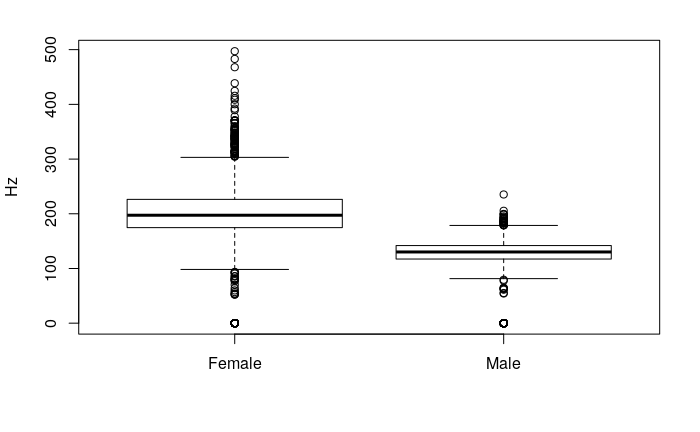

Wniosek jest oczywisty: kobiety mają głosy o wyższej częstotliwości fundamentalnej od mężczyzn. Proszę jednak docenić, jak łatwo osiągnęliśmy ten cel. Od postawienia hipotezy potrzebowaliśmy zaledwie 8 poleceń, żeby otrzymać rysunek nadający się praktycznie do umieszczenia w pracy i wysłania na konferencję!

Inny powód to sam fakt, że bazę zapisaliśmy w formacie EMU. System ten zmusza nas do organizacji własnych nagrań w konkretny sposób i używając specjalnej struktury informacji, ale nagradza nas bardzo przydatnymi narzędziami i wygodą pracy w wyżej zaprezentowany sposób.